# Ford Go Bike 2018

|  | **Udacity** |
| --- | --- |
| **Nanodegree:** | *Data Analyst* |
| **Student:** | *Theresa Kocher* |
| **Date:** | *4th May 2019* |

## Investigation Overview

> In this investigation, we will have a look at the different cities where the bike rent service is located. Then, we will investigate if there are differences between the users in those cities.

## Dataset Overview

> The data consists of the **Ford GoBike**'s trip data that is for public use. For this investigation only the acquired data of the year 2018 were analysed.

We will treat the following **leading questions** in this presentation:

1. Are there more busier rent stations than others?
2. In which cities were the Ford GoBikes rent in 2018?
3. Are there different kind of users in different cities?

## Question 1: Are there more busier rent stations than others?

How busy are those rent stations? Where are the busiest rent stations located?

#### The 40 busiest rent station meassured by the amount of rent/year

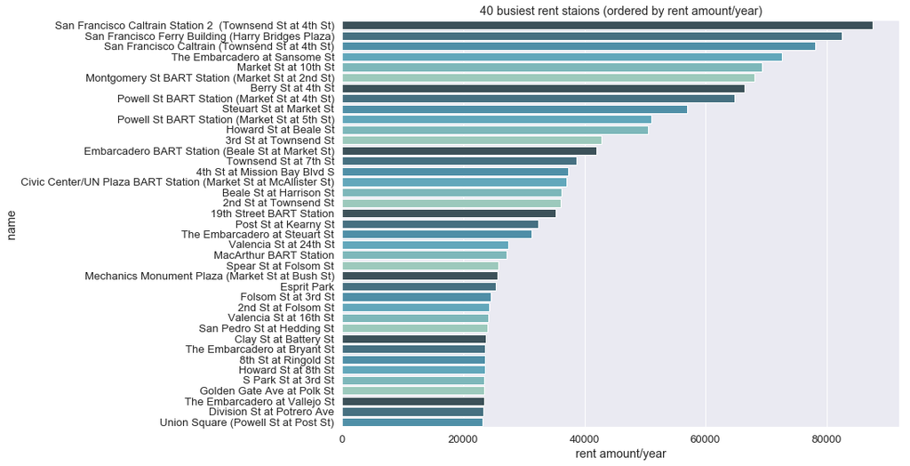

```python
#preparing data
result = rush_stations.groupby(["name"])['amount'].aggregate(np.median).reset_index().sort_values('amount')

# show only left 40 bussyiest stations
fig, ax = fig, ax = plt.subplots()
fig.set_size_inches(12, 9)
ax = sns.barplot(x='amount', y="name", data=rush_stations, order=result['name'].iloc[:308:-1], palette=sns.color_palette("GnBu_d"));
ax.set_xlabel('rent amount/year');
plt.title('40 busiest rent staions (ordered by rent amount/year)');
```

In the above visualization, we can see that the station with the name *San FranciscoCaltrain Station 2 (Townsened St at 4th St)* is the station with the most rents in year 2018.

In total, there are about 10 to 20 more busier stations than others. All other stations are less busy and had more or less the same amount of rents in the year 2018 (about 20000 rents/year). The rents amount per station decreases when ordering the station by its rents amount. After ordering, it is almost logarithmically distributed.

## Question 2: In which cities were the Ford GoBikes rent in 2018?

Where are those rent stations located? Are all in one city or in several?

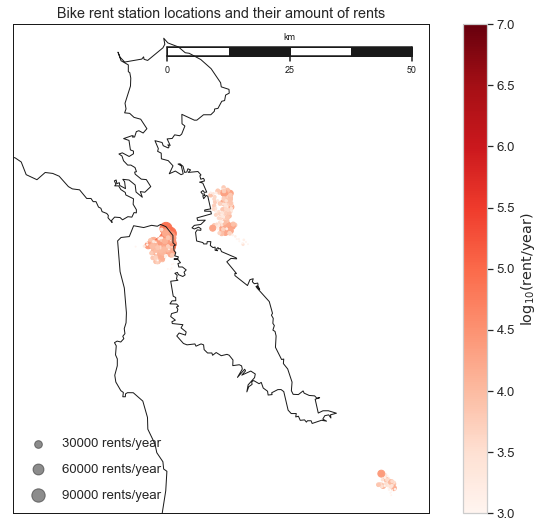

```python
# 1. Draw the map background
fig = plt.figure(figsize=(12, 9))
m = Basemap(projection='tmerc', resolution='h',
            lat_0=mean_latitude, lon_0=mean_longitude,
            width=0.085E6, height=0.1E6)
#m.shadedrelief()
m.drawcoastlines()
m.drawcountries(color='gray')
#m.fillcontinents(color="#cc9955", lake_color="aqua")
m.drawmapboundary()
#m.drawrivers()
#m.drawstates(color='gray')

m.drawmapscale(lon=mean_longitude+0.16, lat=mean_latitude+0.4, lon0=mean_longitude, lat0=mean_latitude, length=50, barstyle='fancy')

# 2. scatter city data, with color reflecting population
# and size reflecting area
m.scatter(lon, lat, latlon=True,
          c=np.log10(amount), s=amount/500,
          cmap='Reds', alpha=1)
#plt.scatter(lon, lat, 10, marker='o', color='red')

#x, y = m(lon, lat) # transform coordinates
#plt.scatter(x,y,10, marker='o', color='red')


plt.title('Bike rent station locations and their amount of rents');
#plt.show()

# 3. create colorbar and legend
plt.colorbar(label=r'$\log_{10}({\rm rent/year})$')
plt.clim(3, 7)

# make legend with dummy points
for a in [30000, 60000, 90000]:
    plt.scatter([], [], c='k', alpha=0.5, s=a/500,
                label=str(a) + ' rents/year')
plt.legend(scatterpoints=1, frameon=False,
           labelspacing=1, loc='lower left');
```

When we plot the station locations into a map, we see that there are three main parts (clusters), where the stations are located. It seems that the rent service has stations in three different cities. Let's try to find out, where the center of those 3 station clusters are. So that we can name them by their city name in an additional feature.

There are three city centers found. When viewing the locations on the map, I can identify the following cities for the found cluster centers: **San Jose**, **San Francisco**, **East Bay**.

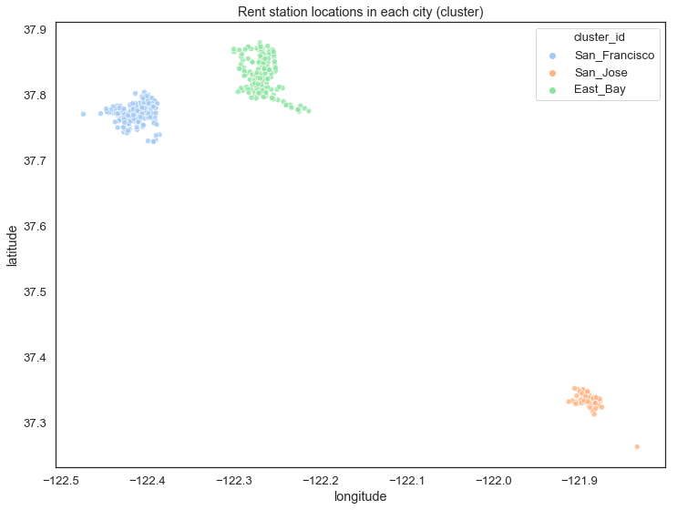

```python
sns.set_style("white")

fig, ax = fig, ax = plt.subplots()
fig.set_size_inches(12, 9)
ax = sns.scatterplot(x="longitude", y="latitude",
                      hue="cluster_id", alpha=.8,
                      data=clustered_stations);
#ax.set_ylim(rush_stations['latitude'].min(), rush_stations['latitude'].max())
ax.set_title("Rent station locations in each city (cluster)");
```

In the following, maps of the 3 cities **San Jose**, **San Francisco**, **East Bay** are shown. We can see the distributed locations of the rent stations in each city and their different amount of rents/year.

#### Bike rent stations in San Francisco

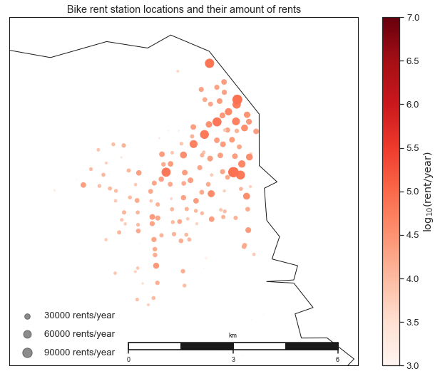

```python
# draw map for first cluster center
center = C[1]

# 1. Draw the map background
fig = plt.figure(figsize=(12, 9))
m = Basemap(projection='tmerc', resolution='h',
            lat_0=center[0], lon_0=center[1],
            width=0.01E6, height=0.01E6)
#m.shadedrelief()
m.drawcoastlines()
m.drawcountries(color='gray')
#m.fillcontinents(color="#cc9955", lake_color="aqua")
m.drawmapboundary()
#m.drawrivers()
#m.drawstates(color='gray')

m.drawmapscale(lon=center[1]+0.016, lat=center[0]-0.04,
               lon0=center[1], lat0=center[0], length=6, barstyle='fancy')

# 2. scatter city data, with color reflecting population
# and size reflecting area
m.scatter(lon, lat, latlon=True,
          c=np.log10(amount), s=amount/500,
          cmap='Reds', alpha=1)
#plt.scatter(lon, lat, 10, marker='o', color='red')

#x, y = m(lon, lat) # transform coordinates
#plt.scatter(x,y,10, marker='o', color='red')


plt.title('Bike rent station locations and their amount of rents');
#plt.show()

# 3. create colorbar and legend
plt.colorbar(label=r'$\log_{10}({\rm rent/year})$')
plt.clim(3, 7)

# make legend with dummy points
for a in [30000, 60000, 90000]:
    plt.scatter([], [], c='k', alpha=0.5, s=a/500,
                label=str(a) + ' rents/year')
plt.legend(scatterpoints=1, frameon=False,
           labelspacing=1, loc='lower left');
```

#### Bike rent stations in East Bay

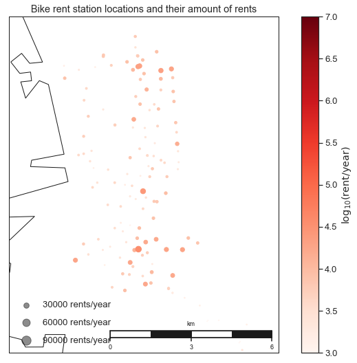

```python
# draw map for first cluster center
center = C[2]

# 1. Draw the map background
fig = plt.figure(figsize=(12, 9))
m = Basemap(projection='tmerc', resolution='h',
            lat_0=center[0], lon_0=center[1],
            width=0.01E6, height=0.0125E6)
#m.shadedrelief()
m.drawcoastlines()
m.drawcountries(color='gray')
#m.fillcontinents(color="#cc9955", lake_color="aqua")
m.drawmapboundary()
#m.drawrivers()
#m.drawstates(color='gray')

m.drawmapscale(lon=center[1]+0.02, lat=center[0]-0.05,
               lon0=center[1], lat0=center[0], length=6, barstyle='fancy')

# 2. scatter city data, with color reflecting population
# and size reflecting area
m.scatter(lon, lat, latlon=True,
          c=np.log10(amount), s=amount/500,
          cmap='Reds', alpha=1)
#plt.scatter(lon, lat, 10, marker='o', color='red')

#x, y = m(lon, lat) # transform coordinates
#plt.scatter(x,y,10, marker='o', color='red')


plt.title('Bike rent station locations and their amount of rents');
#plt.show()

# 3. create colorbar and legend
plt.colorbar(label=r'$\log_{10}({\rm rent/year})$')
plt.clim(3, 7)

# make legend with dummy points
for a in [30000, 60000, 90000]:
    plt.scatter([], [], c='k', alpha=0.5, s=a/500,
                label=str(a) + ' rents/year')
plt.legend(scatterpoints=1, frameon=False,
           labelspacing=1, loc='lower left');
```

#### Bike rent stations in San José

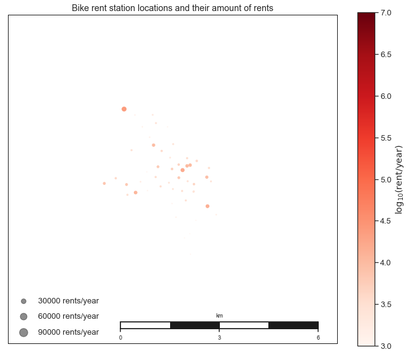

```python
# draw map for first cluster center
center = C[0]

# 1. Draw the map background
fig = plt.figure(figsize=(12, 10))
m = Basemap(projection='tmerc', resolution='h',
            lat_0=center[0], lon_0=center[1],
            width=0.01E6, height=0.01E6)
#m.shadedrelief()
m.drawcoastlines()
m.drawcountries(color='gray')
#m.fillcontinents(color="#cc9955", lake_color="aqua")
m.drawmapboundary()
#m.drawrivers()
#m.drawstates(color='gray')

m.drawmapscale(lon=center[1]+0.016, lat=center[0]-0.04,
               lon0=center[1], lat0=center[0], length=6, barstyle='fancy')

# 2. scatter city data, with color reflecting population
# and size reflecting area
m.scatter(lon, lat, latlon=True,
          c=np.log10(amount), s=amount/500,
          cmap='Reds', alpha=1)
#plt.scatter(lon, lat, 10, marker='o', color='red')

#x, y = m(lon, lat) # transform coordinates
#plt.scatter(x,y,10, marker='o', color='red')


plt.title('Bike rent station locations and their amount of rents');
#plt.show()

# 3. create colorbar and legend
plt.colorbar(label=r'$\log_{10}({\rm rent/year})$')
plt.clim(3, 7)

# make legend with dummy points
for a in [30000, 60000, 90000]:
    plt.scatter([], [], c='k', alpha=0.5, s=a/500,
                label=str(a) + ' rents/year')
plt.legend(scatterpoints=1, frameon=False,
           labelspacing=1, loc='lower left');
```

### Question 3: Are there different kind of users in different cities?

Do the users in the different cities are different in their distribution of age or gender?

#### User's gender in each city

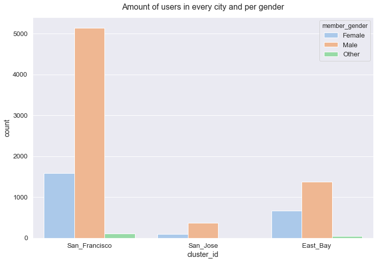

```python
fig.set_size_inches(12, 9)
ax1 = sns.countplot(data = rent_sample, x = 'cluster_id', hue = 'member_gender');
ax1.set_title("Amount of users in every city and per gender", y=1.02,fontsize=16);
```

In the above plot we can see the count of users (every rent counts as one individual user) per city (x-axis) and per gender (colors).

#### Average age of users per gender

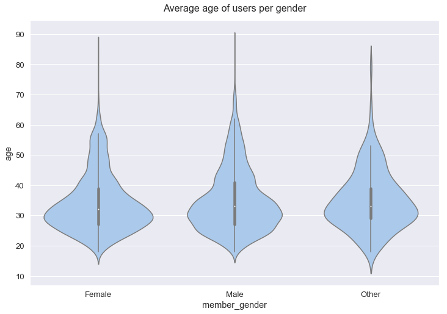

```python
fig.set_size_inches(12, 9)
# left plot: violin plot
ax1 = sns.violinplot(data = rent_sample, x = 'member_gender', y = 'age', color = base_color)
ax1.set_title("Average age of users per gender", y=1.02,fontsize=16);
```

In the above plot we can see, that the average age of female users is 33.7 and of male users is 35.3 years old.

#### Average age of users per city

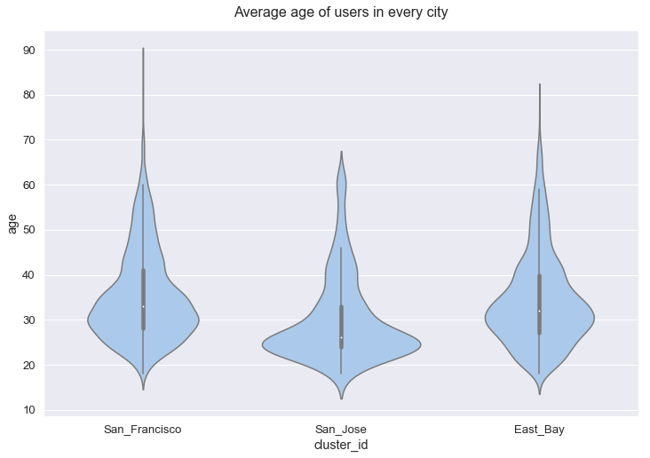

```python
fig.set_size_inches(12, 9)

# left plot: violin plot
#plt.subplot(1, 2, 1)
ax1 = sns.violinplot(data = rent_sample, x = 'cluster_id', y = 'age', color = base_color)
ax1.set_title("Average age of users in every city", y=1.02,fontsize=16);
```

More interesting is the average age of the different cities. In San Francisco the user age's average is over 35, in East Bay about 34 and in San Jose the average age is 30 and less distributed over all ages.

#### Distribution of user's age per gender and city

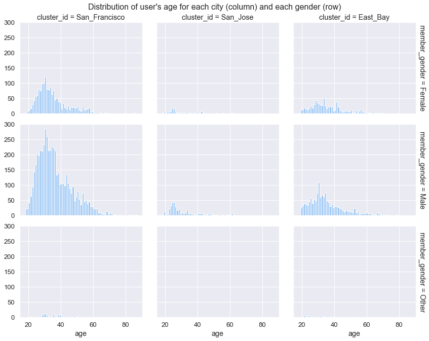

```python
#fig, ax = fig, ax = plt.subplots()

bins = np.arange(rent_sample['age'].min(), rent_sample['age'].max()+1, 1);

g = sns.FacetGrid(data = rent_sample, col = 'cluster_id', row = 'member_gender', height = 4,
                margin_titles = True);
g.map(plt.hist, 'age', bins = bins);
g.fig.set_size_inches(12, 9)
g.fig.suptitle("Distribution of user's age for each city (column) and each gender (row)", y=1.02,fontsize=16);
```

In this plot, we can see the distribution of user's age for every gender (rows) in every city (columns). Beside that, we can see that San Francisco has the most users and San Jose the fewest.

### Summary

The insights showed, that there are 3 cities, where the rent service is provided and where rent stations are located.

With a clustering of the rent station locations, we could provide the city labels for each station and rent data entry. With that label, we did investigate an analysis on user's age and gender in the different cities.

### Suprising results?

In San Francisco and San Jose only 1/5 of the users are female. Whereas in East Bay about 1/3 are female. So, most users are male in every city.

The most users are allocated in San Francisco (not suprising).